# Matilda_CMML_methylation_ChromHMM_2023

xiangfu

2023-09-06

**UPDATE NOTE**

- currently, we still have chromatin states from chrX/Y. need to be removed
- annotated enhancers to genes, and write to tsv files
- added DMRs

## filtering DMPs

filtering DMPs by `adj.P.Val < 0.01 & abs(logFC) >= 0.1`, 48148 DMPs left. Among them, 43104 sites were hypermethylated (logFC > 0); 5044 sits were hypomethylated (logFC < 0)

```r
## number of sites included in the received data
nrow(DMP_data)
```

```
## [1] 736378
```

```r
## correct the comparison set
DMP_data$logFC <- DMP_data$logFC * -1

## subset significant DMPs
DMP_data.sig <- DMP_data %>% dplyr::filter(adj.P.Val < 0.01 & abs(logFC) >= 0.1)

## number of significant DMPs
nrow(DMP_data.sig)
```

```
## [1] 48148
```

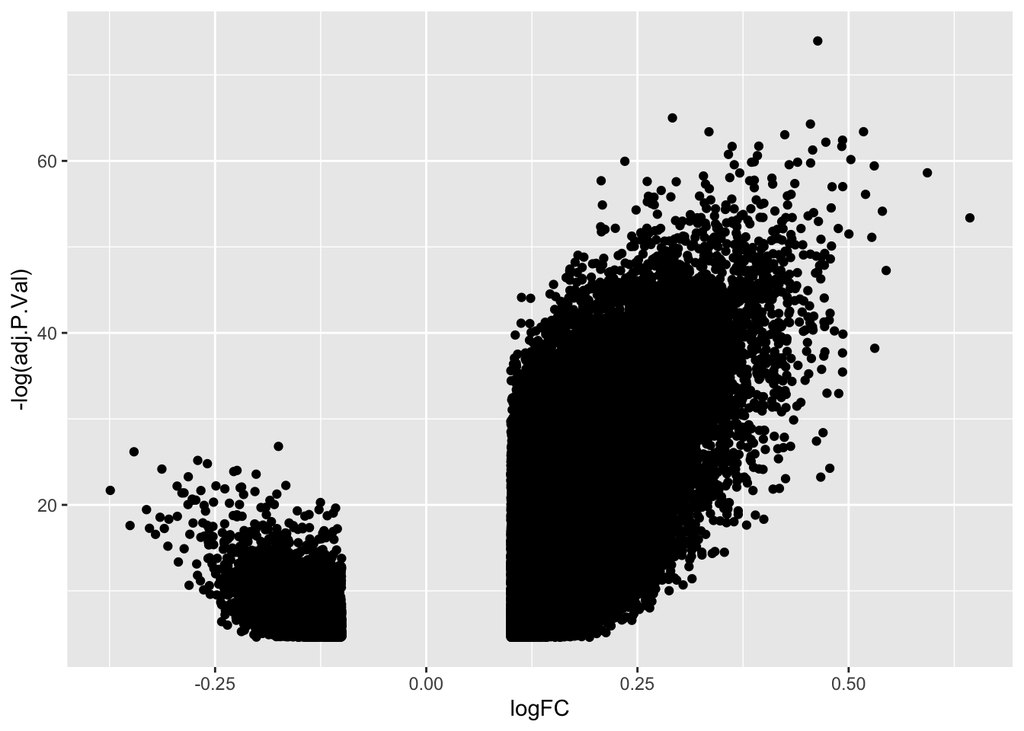

```r
## hyper/hypo methylated sites
DMP_data.sig.hyper <- DMP_data.sig %>% dplyr::filter(logFC > 0)
DMP_data.sig.hypo <- DMP_data.sig %>% dplyr::filter(logFC < 0)

## double check
DMP_data.sig %>% ggplot(aes(x=logFC, y=-log(adj.P.Val))) +geom_point()
```

```r
# table(DMP_data.sig.hyper$CHR)
# table(DMP_data.sig.hypo$CHR)
# table(DMP_data.sig$CHR)
```

export significant sites to bed files

```r
DMP_data.sig %>% dplyr::mutate(CHR=paste0("chr", CHR))  %>% dplyr::mutate(start=MAPINFO) %>% dplyr::mutate(end=MAPINFO+1) %>% dplyr::select(CHR, start, end) %>% readr::write_delim(file=paste0(CMML_dataPath, "methyChromHMM/sigDMPs.bed"), delim="\t", col_names = FALSE)

DMP_data.sig.hyper %>% dplyr::mutate(CHR=paste0("chr", CHR))  %>% dplyr::mutate(start=MAPINFO) %>% dplyr::mutate(end=MAPINFO+1) %>% dplyr::select(CHR, start, end) %>% readr::write_delim(file=paste0(CMML_dataPath, "methyChromHMM/sigHyperDMPs.bed"), delim="\t", col_names = FALSE)

DMP_data.sig.hypo %>% dplyr::mutate(CHR=paste0("chr", CHR))  %>% dplyr::mutate(start=MAPINFO) %>% dplyr::mutate(end=MAPINFO+1) %>% dplyr::select(CHR, start, end) %>% readr::write_delim(file=paste0(CMML_dataPath, "methyChromHMM/sigHypoDMPs.bed"), delim="\t", col_names = FALSE)
```

## DMPs in Monocyte chromatin states

### chromatin state data retrieve

we are using chromatin states from here [ChromHMM 18-state model for Monocytes-CD14+ RO01746 Primary Cells](https://www.encodeproject.org/annotations/ENCSR907LCD/). `ENCFF072SCA.bigBed` was downloaded. And convert it to `ENCFF072SCA.bed` by using [**bigBedToBed**](https://genome.ucsc.edu/goldenPath/help/bigBed.html).

the model has 18 chromatin states as following:

```r
ENCFF072SCA.bed <- rtracklayer::import(paste0(CMML_dataPath, "RoadMap/ENCFF072SCA.bed"))
unique(ENCFF072SCA.bed$name)
```

```
##  [1] "18_Quies"    "13_Het"      "12_ZNF/Rpts" "6_TxWk"      "5_Tx"
##  [6] "11_EnhWk"    "1_TssA"      "3_TssFlnkU"  "4_TssFlnkD"  "2_TssFlnk"
## [11] "9_EnhA1"     "10_EnhA2"    "17_ReprPCWk" "16_ReprPC"   "15_EnhBiv"
## [16] "14_TssBiv"   "7_EnhG1"     "8_EnhG2"
```

| STATE NO. | MNEMONIC | DESCRIPTION |  |
| --- | --- | --- | --- |
| 1 | TssA | Active TSS |  |
| 2 | TssFlnk | Flanking TSS |  |
| 3 | TssFlnkU | Flanking TSS Upstream |  |
| 4 | TssFlnkD | Flanking TSS Downstream |  |
| 5 | Tx | Strong transcription |  |
| 6 | TxWk | Weak transcription |  |
| 7 | EnhG1 | Genic enhancer1 |  |
| 8 | EnhG2 | Genic enhancer2 |  |
| 9 | EnhA1 | Active Enhancer 1 |  |
| 10 | EnhA2 | Active Enhancer 2 |  |
| 11 | EnhWk | Weak Enhancer |  |
| 12 | ZNF/Rpts | ZNF genes & repeats |  |
| 13 | Het | Heterochromatin |  |
| 14 | TssBiv | Bivalent/Poised TSS |  |
| 15 | EnhBiv | Bivalent Enhancer |  |
| 16 | ReprPC | Repressed PolyComb |  |
| 17 | ReprPCWk | Weak Repressed PolyComb |  |
| 18 | Quies | Quiescent/Low |  |

[Summarized visualization of chromatin states](https://egg2.wustl.edu/roadmap/data/byFileType/chromhmmSegmentations/ChmmModels/core_K27ac/jointModel/final/annotationEnrichment_RoadmapEp_core_K27ac_18State.png)

### run chromHMM

```bash
cd /Users/xiangfu.zhong/Library/CloudStorage/OneDrive-KarolinskaInstitutet/Matilda_CMML_methylation_ChromHMM_2023/methyChromHMM

### all significant DMPs
java -jar /Users/xiangfu.zhong/Documents/RESEARCH.KI/chromatinState/ChromHMM/ChromHMM.jar  OverlapEnrichment -labels /Users/xiangfu.zhong/Library/CloudStorage/OneDrive-KarolinskaInstitutet/Matilda_CMML_methylation_ChromHMM_2023/RoadMap/ENCFF072SCA.bed /Users/xiangfu.zhong/Library/CloudStorage/OneDrive-KarolinskaInstitutet/Matilda_CMML_methylation_ChromHMM_2023/methyChromHMM/sigDMPs.bed  /Users/xiangfu.zhong/Library/CloudStorage/OneDrive-KarolinskaInstitutet/Matilda_CMML_methylation_ChromHMM_2023/methyChromHMM/sigDMPs_within_chromatinStates

### hypermethylated DMPs
java -jar /Users/xiangfu.zhong/Documents/RESEARCH.KI/chromatinState/ChromHMM/ChromHMM.jar  OverlapEnrichment -labels /Users/xiangfu.zhong/Library/CloudStorage/OneDrive-KarolinskaInstitutet/Matilda_CMML_methylation_ChromHMM_2023/RoadMap/ENCFF072SCA.bed /Users/xiangfu.zhong/Library/CloudStorage/OneDrive-KarolinskaInstitutet/Matilda_CMML_methylation_ChromHMM_2023/methyChromHMM/sigHyperDMPs.bed  /Users/xiangfu.zhong/Library/CloudStorage/OneDrive-KarolinskaInstitutet/Matilda_CMML_methylation_ChromHMM_2023/methyChromHMM/sigHyperDMPs_within_chromatinStates

### hypomethylated DMPs
java -jar /Users/xiangfu.zhong/Documents/RESEARCH.KI/chromatinState/ChromHMM/ChromHMM.jar  OverlapEnrichment -labels /Users/xiangfu.zhong/Library/CloudStorage/OneDrive-KarolinskaInstitutet/Matilda_CMML_methylation_ChromHMM_2023/RoadMap/ENCFF072SCA.bed /Users/xiangfu.zhong/Library/CloudStorage/OneDrive-KarolinskaInstitutet/Matilda_CMML_methylation_ChromHMM_2023/methyChromHMM/sigHypoDMPs.bed  /Users/xiangfu.zhong/Library/CloudStorage/OneDrive-KarolinskaInstitutet/Matilda_CMML_methylation_ChromHMM_2023/methyChromHMM/sigHypoDMPs_within_chromatinStates
```

### visualization

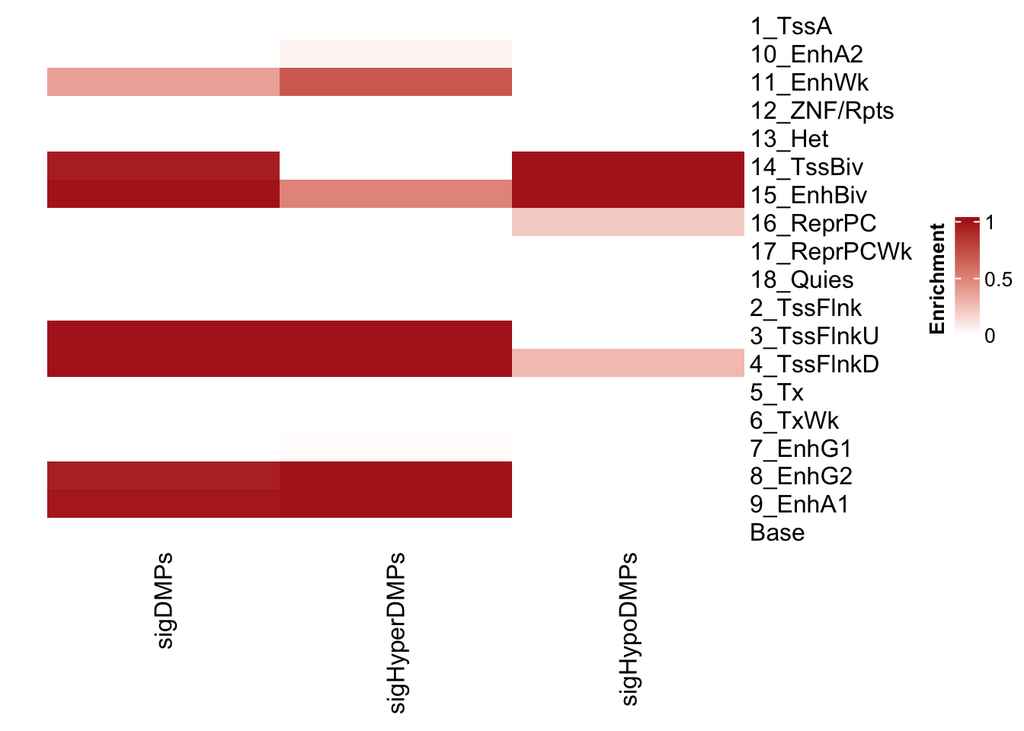

```r
sigDMPs.chromhmm <- readr::read_tsv( paste0( CMML_dataPath, "methyChromHMM/sigDMPs_within_chromatinStates.txt"), locale=locale(decimal_mark = ","))
colnames(sigDMPs.chromhmm) <- c("states", "Genome", "sigDMPs")

sigHyperDMPs.chromhmm <- readr::read_tsv( paste0( CMML_dataPath, "methyChromHMM/sigHyperDMPs_within_chromatinStates.txt"), locale=locale(decimal_mark = ","))
colnames(sigHyperDMPs.chromhmm) <- c("states", "Genome", "sigHyperDMPs")

sigHypoDMPs.chromhmm <- readr::read_tsv( paste0( CMML_dataPath, "methyChromHMM/sigHypoDMPs_within_chromatinStates.txt"), locale=locale(decimal_mark = ","))
colnames(sigHypoDMPs.chromhmm) <- c("states", "Genome", "sigHypoDMPs")


pooledChromhmm  <- merge(sigDMPs.chromhmm[, c("states", "sigDMPs")], sigHyperDMPs.chromhmm[, c("states", "sigHyperDMPs")], by="states")
pooledChromhmm <- merge(pooledChromhmm, sigHypoDMPs.chromhmm[, c("states", "sigHypoDMPs")], by="states")
rownames(pooledChromhmm) <- pooledChromhmm$states
pooledChromhmm <- pooledChromhmm[,-1]

ComplexHeatmap::Heatmap(scale(pooledChromhmm), heatmap_legend_param = list(title = "Enrichment", title_position = "leftcenter-rot"), cluster_rows = FALSE, cluster_columns = FALSE,  col=circlize::colorRamp2(c(0,  1), c("white", "firebrick")), show_column_dend = FALSE, show_row_names = TRUE, row_names_side = "right", row_title = " ")
```

### site proportion

[Tulstrup *et al.* 2021, Nature Communications](https://doi.org/10.1038/s41467-021-26093-2) they actually used site proportion, not a function from ChromHMM.

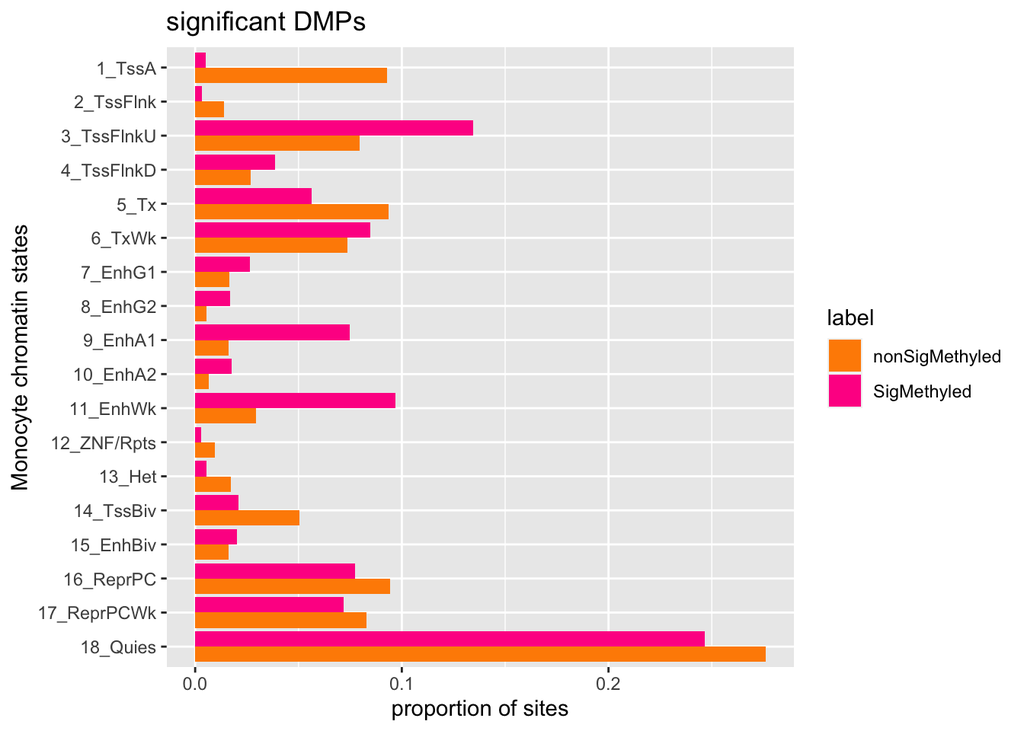

```r
stateFactor <- lapply(unique(ENCFF072SCA.bed$name), function(x) str_split(x, "_")[[1]][1]) %>% unlist()  %>% as.numeric()
names(stateFactor) <- unique(ENCFF072SCA.bed$name)

#### function to get proportion of sites within chromatin states ####
getOverlapproportion <- function(queryDMPtab, setLabel, totalDMPtab, chrStateBed){
  states <- unique(chrStateBed$name)
  Nquery <- nrow(queryDMPtab)
  nonQueryTab <- totalDMPtab %>% dplyr::filter(!.$...1 %in% queryDMPtab$...1)
  NnonQuery <- nrow(nonQueryTab)

  queryBed <- queryDMPtab %>% dplyr::mutate(CHR=paste0("chr", CHR))  %>% dplyr::mutate(start=MAPINFO) %>% dplyr::mutate(end=MAPINFO+1) %>% dplyr::select(CHR, start, end)  %>% GenomicRanges::GRanges()
  nonQueryBed <- nonQueryTab %>% dplyr::mutate(CHR=paste0("chr", CHR))  %>% dplyr::mutate(start=MAPINFO) %>% dplyr::mutate(end=MAPINFO+1) %>% dplyr::select(CHR, start, end)  %>% GenomicRanges::GRanges()

  chromhmmProportion <- data.frame()

  for(istate in states){
    istateBed <- chrStateBed[chrStateBed$name==istate, ]
    # istateBed <- chrStateBed %>% as.data.frame() %>% dplyr::filter(name == istate)  %>% GenomicRanges::GRanges()

    queryCount <- GenomicRanges::findOverlaps(queryBed, istateBed) %>% as.data.frame() %>% dplyr::select(queryHits) %>% unlist() %>% unique() %>% length()
    nonQueryCount <- GenomicRanges::findOverlaps(nonQueryBed, istateBed) %>% as.data.frame() %>% dplyr::select(queryHits) %>% unlist() %>% unique() %>% length()

    chromhmmProportion <- rbind(data.frame(state=istate, label=setLabel, proportion=queryCount/as.double(Nquery), totalCount=as.double(Nquery)), chromhmmProportion)
    chromhmmProportion <- rbind(data.frame(state=istate, label=paste0("non",setLabel), proportion=nonQueryCount/as.double(NnonQuery), totalCount=as.double(NnonQuery)), chromhmmProportion)
  }
  return(chromhmmProportion)
}

#### significant DMPs ####
proportion.DMPsig <- getOverlapproportion(DMP_data.sig, "SigMethyled", DMP_data, ENCFF072SCA.bed)
proportion.DMPsig$state <- factor(proportion.DMPsig$state, levels = names(sort(-stateFactor)))

proportion.DMPsig %>% ggplot2::ggplot(aes(x=proportion, y=state, fill=label)) +geom_bar(stat="identity", position="dodge") +xlab("proportion of sites") +ylab("Monocyte chromatin states") +ggtitle("significant DMPs") +scale_fill_manual(values=c("SigMethyled"="deeppink", "nonSigMethyled"="darkorange"))
```

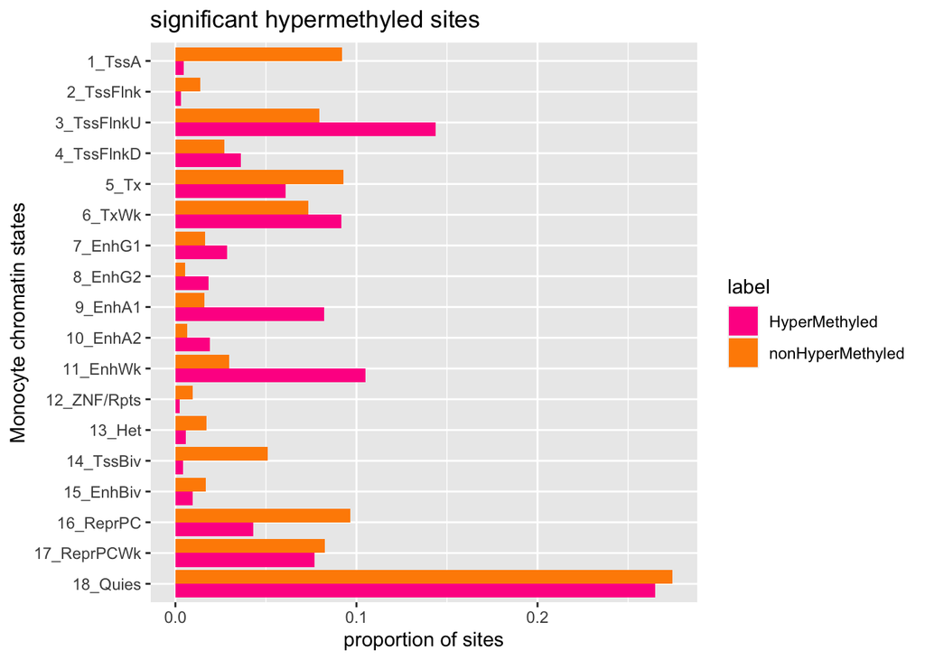

```r
##### significant hypermethyled sites ####
proportion.DMPsig.hyper <- getOverlapproportion(DMP_data.sig.hyper, "HyperMethyled", DMP_data, ENCFF072SCA.bed)
proportion.DMPsig.hyper$state <- factor(proportion.DMPsig.hyper$state, levels = names(sort(-stateFactor)))

proportion.DMPsig.hyper %>% ggplot2::ggplot(aes(x=proportion, y=state, fill=label)) +geom_bar(stat="identity", position="dodge") +xlab("proportion of sites") +ylab("Monocyte chromatin states") +ggtitle("significant hypermethyled sites") +scale_fill_manual(values=c("HyperMethyled"="deeppink", "nonHyperMethyled"="darkorange"))
```

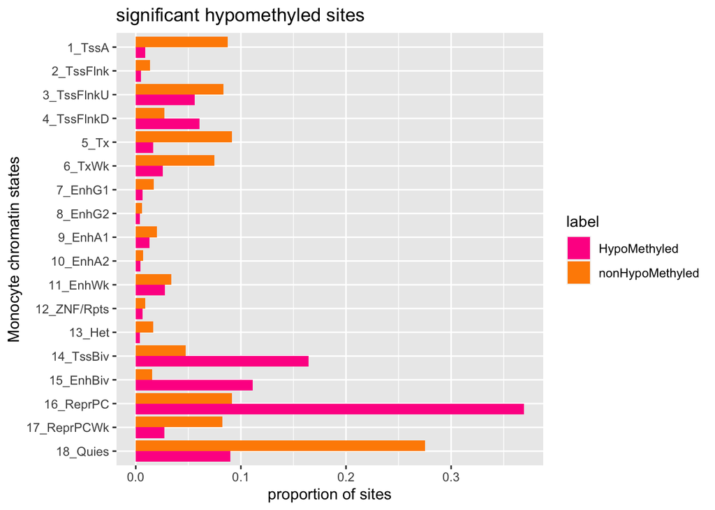

```r
##### significant hypomethyled sites ####
proportion.DMPsig.hypo <- getOverlapproportion(DMP_data.sig.hypo, "HypoMethyled", DMP_data, ENCFF072SCA.bed)
proportion.DMPsig.hypo$state <- factor(proportion.DMPsig.hypo$state, levels = names(sort(-stateFactor)))

proportion.DMPsig.hypo %>% ggplot2::ggplot(aes(x=proportion, y=state, fill=label)) +geom_bar(stat="identity", position="dodge") +xlab("proportion of sites") +ylab("Monocyte chromatin states") +ggtitle("significant hypomethyled sites") +scale_fill_manual(values=c("HypoMethyled"="deeppink", "nonHypoMethyled"="darkorange"))
```

#### site proportion of merged enhancer set

HyperMethyled site proportion of merged enhancer set:

enhancers:

- 7_EnhG1: Genic enhancer1
- 8_EnhG2: Genic enhancer2
- 9_EnhA1: Active Enhancer 1
- 10_EnhA2: Active Enhancer 2
- 11_EnhWk: Weak Enhancer

```r
enhancerBed <-  ENCFF072SCA.bed  %>% as.data.frame() %>% dplyr::filter(name %in% c("7_EnhG1", "8_EnhG2", "9_EnhA1", "10_EnhA2", "11_EnhWk" ))  %>% GenomicRanges::GRanges()

HyperMethyled.bed <- DMP_data.sig.hyper %>% dplyr::mutate(CHR=paste0("chr", CHR))  %>% dplyr::mutate(start=MAPINFO) %>% dplyr::mutate(end=MAPINFO+1) %>% dplyr::select(CHR, start, end)  %>% GenomicRanges::GRanges()

nonHyperMethyled.bed <- DMP_data %>% dplyr::filter(!.$...1 %in% HyperMethyled.bed$...1) %>% dplyr::mutate(CHR=paste0("chr", CHR))  %>% dplyr::mutate(start=MAPINFO) %>% dplyr::mutate(end=MAPINFO+1) %>% dplyr::select(CHR, start, end)  %>% GenomicRanges::GRanges()

hyperDMP_in_enhancer.count <- GenomicRanges::findOverlaps(HyperMethyled.bed, enhancerBed) %>% as.data.frame() %>% dplyr::select(queryHits) %>% unlist() %>% unique() %>% length()

nonHyperDMP_in_enhancer.count <- GenomicRanges::findOverlaps(nonHyperMethyled.bed, enhancerBed) %>% as.data.frame() %>% dplyr::select(queryHits) %>% unlist() %>% unique() %>% length()

# hyperDMP_in_enhancer.count/as.double(length(HyperMethyled.bed))
# nonHyperDMP_in_enhancer.count/as.double(length(nonHyperMethyled.bed))

sprintf("The proportion of hyper methyled sites (%s) within enhancers is: %s", length(HyperMethyled.bed), hyperDMP_in_enhancer.count/as.double(length(HyperMethyled.bed)))
```

```
## [1] "The proportion of hyper methyled sites (43104) within enhancers is: 0.253155159613957"
```

```r
sprintf("The proportion of nonhyper methyled sites (%s) within enhancers is: %s", length(nonHyperMethyled.bed), nonHyperDMP_in_enhancer.count/as.double(length(nonHyperMethyled.bed)))
```

```
## [1] "The proportion of nonhyper methyled sites (736378) within enhancers is: 0.0843018123844004"
```

#### enhancers have multiple hyper methyled sites

OUTPUT FILE: `multiple_HyperMethyled_in_enhancers.tsv`

```r
library(TxDb.Hsapiens.UCSC.hg38.knownGene)
txdb <- TxDb.Hsapiens.UCSC.hg38.knownGene

enhancer_buff <- data.frame()
for(iEnhType in c("7_EnhG1", "8_EnhG2", "9_EnhA1", "10_EnhA2", "11_EnhWk" )){
  iEnhType_enhancerBed <- enhancerBed[enhancerBed$name == iEnhType,]
  i_hyperDMP_in_enhancer <- GenomicRanges::findOverlaps(HyperMethyled.bed, iEnhType_enhancerBed)
  i_summaryTab <- subjectHits(i_hyperDMP_in_enhancer) %>% table() %>% as.data.frame() %>% dplyr::filter(Freq >1) %>% dplyr::rename(subjectHits='.')
  iTargetEnhancer <- iEnhType_enhancerBed[as.numeric(unfactor(i_summaryTab$subjectHits))]
  values(iTargetEnhancer) <- data.frame(siteCount = i_summaryTab$Freq)
  iTargetEnhancer.peakAnno <- ChIPseeker::annotatePeak(iTargetEnhancer, tssRegion=c(-3000, 3000),  TxDb=txdb, annoDb="org.Hs.eg.db", verbose =FALSE) %>% as.data.frame()

  enhancer_buff <- rbind(data.frame(iTargetEnhancer.peakAnno, enhancerGroup=iEnhType), enhancer_buff)

  ipathway <- ReactomePA::enrichPathway(iTargetEnhancer.peakAnno$geneId)
  if(nrow(ipathway) >0) {
    print(paste0("Enhancers from which overlapped with multiple hyper methyled sites, are enriched in following pathways:", iEnhType))
    ipathway %>% as.data.frame() %>% dplyr::select(Description) %>% unlist() %>%  as.vector() %>% print()
  }
}
```

```
## [1] "Enhancers from which overlapped with multiple hyper methyled sites, are enriched in following pathways:7_EnhG1"
##  [1] "Signaling by NOTCH4"
##  [2] "Transcriptional regulation by RUNX3"
##  [3] "Negative regulation of NOTCH4 signaling"
##  [4] "Regulation of RAS by GAPs"
##  [5] "Fc epsilon receptor (FCERI) signaling"
##  [6] "MAPK6/MAPK4 signaling"
##  [7] "MAPK family signaling cascades"
##  [8] "Diseases of signal transduction by growth factor receptors and second messengers"
##  [9] "Physiological factors"
## [10] "Cross-presentation of soluble exogenous antigens (endosomes)"
## [11] "Apoptosis"
## [12] "Regulation of activated PAK-2p34 by proteasome mediated degradation"
## [13] "Regulation of ornithine decarboxylase (ODC)"
## [14] "Vpu mediated degradation of CD4"
```

[output cut: 77 more lines]

```r
readr::write_tsv(enhancer_buff, file=paste0(CMML_dataPath, "resultTables_CMML_to_Matild/multiple_HyperMethyled_in_enhancers.tsv"), progress = FALSE)
```

#### annotate query enhancers to genes

OUTPUT FILE: `HyperMethyled_in_enhancers.tsv`

```r
enhancer_buff <- data.frame()

for(iEnhType in c("7_EnhG1", "8_EnhG2", "9_EnhA1", "10_EnhA2", "11_EnhWk" )){
  iEnhType_enhancerBed <- enhancerBed[enhancerBed$name == iEnhType,]
  i_hyperDMP_in_enhancer <- GenomicRanges::findOverlaps(HyperMethyled.bed, iEnhType_enhancerBed)
  i_summaryTab <- subjectHits(i_hyperDMP_in_enhancer)  %>% table() %>% as.data.frame()  %>% dplyr::rename(subjectHits='.')
  iTargetEnhancer <- iEnhType_enhancerBed[as.numeric(unfactor(i_summaryTab$subjectHits))]
  values(iTargetEnhancer) <- data.frame(siteCount = i_summaryTab$Freq)
  iTargetEnhancer.peakAnno <- ChIPseeker::annotatePeak(iTargetEnhancer, tssRegion=c(-3000, 3000),  TxDb=txdb, annoDb="org.Hs.eg.db", verbose =FALSE) %>% as.data.frame()

  enhancer_buff <- rbind(data.frame(iTargetEnhancer.peakAnno, enhancerGroup=iEnhType), enhancer_buff)
}
readr::write_tsv(enhancer_buff, file=paste0(CMML_dataPath, "resultTables_CMML_to_Matild/HyperMethyled_in_enhancers.tsv"), progress = FALSE)
```

#### hypo methyled sites on TssBiv, EnhBiv, ReprPC

OUTPUT FILE: `HypoMethyled_in_chromatinStates.tsv`

```r
HypoMethyled.bed <- DMP_data.sig.hypo %>% dplyr::mutate(CHR=paste0("chr", CHR))  %>% dplyr::mutate(start=MAPINFO) %>% dplyr::mutate(end=MAPINFO+1) %>% dplyr::select(CHR, start, end)  %>% GenomicRanges::GRanges()

hypo_buff <- data.frame()

for(istate in c("14_TssBiv", "15_EnhBiv", "16_ReprPC" )){
  istateBed <- ENCFF072SCA.bed[ENCFF072SCA.bed$name == istate,]
  i_hypoDMP_in_state <- GenomicRanges::findOverlaps(HypoMethyled.bed, istateBed)
  i_summaryTab <- subjectHits(i_hypoDMP_in_state) %>% table() %>% as.data.frame()  %>% dplyr::rename(subjectHits='.')

  iTargetRegions <- istateBed[as.numeric(unfactor(i_summaryTab$subjectHits))]
  values(iTargetRegions) <- data.frame(siteCount = i_summaryTab$Freq)
  iTargetRegions.peakAnno <- ChIPseeker::annotatePeak(iTargetRegions, tssRegion=c(-3000, 3000),  TxDb=txdb, annoDb="org.Hs.eg.db", verbose =FALSE) %>% as.data.frame()

  hypo_buff <- rbind(data.frame(iTargetRegions.peakAnno, state=istate), hypo_buff)

  ipathway <- ReactomePA::enrichPathway(iTargetRegions.peakAnno$geneId)
  if(nrow(ipathway) >0) {
    print(paste0("Regions which overlapped with hypo methyled sites, are enriched in following pathways:", istate))
    ipathway %>% as.data.frame() %>% dplyr::select(Description) %>% unlist() %>%  as.vector() %>% print()
  }
}
```

```
## [1] "Regions which overlapped with hypo methyled sites, are enriched in following pathways:16_ReprPC"
## [1] "Neuronal System"    "Potassium Channels"
```

```r
readr::write_tsv(hypo_buff, file=paste0(CMML_dataPath, "resultTables_CMML_to_Matild/HypoMethyled_in_chromatinStates.tsv"), progress = FALSE)
```

## DMR in Monocyte chromatin states

Matilda used following to generate DMRs:

```
myDMR <- champ.DMR(beta=myNorm,
              pheno=annotation1$cluster_DNAmethyl_new,
              compare.group= c("mC_1","mC_2"),
              arraytype="EPIC",
              method = "Bumphunter",
              minProbes=7,    #only select DMRs contain more than minProbes (default = 7)
              adjPvalDmr=0.01, #(default = 0.05) all would take too much time and we decided for this cut off
             cores=2,
              ## following parameters are specifically for Bumphunter method.
              maxGap=300,     #maximum length for a DMR (default = 300)
              cutoff=NULL,
              pickCutoff=TRUE,
              smooth=TRUE,
              smoothFunction=loessByCluster,
              useWeights=FALSE,
              permutations=NULL,
              B=250,
              nullMethod="bootstrap")
```

OUTPUT FILE: `DMR_annotation.tsv`

```r
DMR_data <- readr::read_delim(paste0(CMML_dataPath, "Matilda_data/DMRs_mC1_mC2_20230904.csv"), delim=";",locale=locale(decimal_mark = ","), progress=FALSE )

nrow(DMR_data)
```

```
## [1] 342
```

```r
DMR_data.bed  <- DMR_data %>% dplyr::select(seqnames, start, end, strand)  %>% GenomicRanges::GRanges()

find_DMR_overlaps <- GenomicRanges::findOverlaps(DMR_data.bed, ENCFF072SCA.bed)

# DMR_data.bed[queryHits(find_DMR_overlaps)]
oberlapped_states <- ENCFF072SCA.bed[(subjectHits(find_DMR_overlaps))]

overlapped_states.peakAnno <- ChIPseeker::annotatePeak(oberlapped_states, tssRegion=c(-3000, 3000),  TxDb=txdb, annoDb="org.Hs.eg.db", verbose =FALSE) %>% as.data.frame()

table(overlapped_states.peakAnno$name)
```

```
##
##      1_TssA    10_EnhA2    11_EnhWk 12_ZNF/Rpts      13_Het   14_TssBiv
##          15           1          19           5           1         106
##   15_EnhBiv   16_ReprPC 17_ReprPCWk    18_Quies   2_TssFlnk  3_TssFlnkU
##          80         216           9          15           4          41
##  4_TssFlnkD        5_Tx      6_TxWk     7_EnhG1     8_EnhG2     9_EnhA1
##          25           8          11           2           2          11
```

```r
ReactomePA::enrichPathway(overlapped_states.peakAnno$geneId)
```

```
## #
## # over-representation test
## #
## #...@organism     human
## #...@ontology     Reactome
## #...@keytype      ENTREZID
## #...@gene     chr [1:327] "100130872" "3113" "124583" "23293" "493" "57571" "441581" ...
## #...pvalues adjusted by 'BH' with cutoff <0.05
## #...0 enriched terms found
## #...Citation
##   Guangchuang Yu, Qing-Yu He. ReactomePA: an R/Bioconductor package for
##   reactome pathway analysis and visualization. Molecular BioSystems
##   2016, 12(2):477-479
```

```r
DMR_data.peakAnno <- ChIPseeker::annotatePeak(DMR_data.bed, tssRegion=c(-3000, 3000),  TxDb=txdb, annoDb="org.Hs.eg.db", verbose =FALSE) %>% as.data.frame()
ReactomePA::enrichPathway(DMR_data.peakAnno$geneId)
```

```
## #
## # over-representation test
## #
## #...@organism     human
## #...@ontology     Reactome
## #...@keytype      ENTREZID
## #...@gene     chr [1:319] "100130872" "3113" "124583" "23293" "677843" "57571" "441581" ...
## #...pvalues adjusted by 'BH' with cutoff <0.05
## #...0 enriched terms found
## #...Citation
##   Guangchuang Yu, Qing-Yu He. ReactomePA: an R/Bioconductor package for
##   reactome pathway analysis and visualization. Molecular BioSystems
##   2016, 12(2):477-479
```

```r
readr::write_tsv(DMR_data.peakAnno, file=paste0(CMML_dataPath, "resultTables_CMML_to_Matild/DMR_annotation.tsv"), progress = FALSE)
```